# MTH6139 Time Series

Coursework 1

Akila Weerakkody

12/03/2025

# Section 1: What is this project?

In this project, I will explore the data regarding the monthly atmospheric concentration level of carbon dioxide measured at the Mauna Loa Observatory in Hawaii and see whether there are any trends or seasonality within the data. In addition, I will attempt to use historical data to predict future levels of carbon dioxide concentration within the atmosphere.

## 1.1: What is a time series?

A time series is a sequence of data points which are recorded over a period of time at regular time intervals. Time series are particularly useful for analysis as it allows us to look at changes over time and as a result, observe whether there are any trends or seasonal patterns to the data. In addition, the findings from analysing time series can be beneficial as it could lead to new policies or spearhead changes which could have a positive impact.

## 1.2: What data do we have?

The data that I am using in this project is the co2 time series data that can be found within R. This data contains monthly readings of the atmospheric concentrations of carbon dioxide measured in the air in Hawaii between January 1959 and December 1997 With the exceptions of February, March and April in 1964 which were missing and have since been replaced through linear interpolation between the values of January and May of 1964.

## 1.3: How will the predictions be made

For this project, I will be using a forecasting tool called `Prophet`, which has been developed by Meta. It is quite useful for this task as it is able to detect seasonal patterns and trend changes within the data.

# Section 2: Working on the data

## 2.1: Producing the prediction

The first step was to turn the time series into a data frame which could then subsequently be used to produce the predicted results. `ds` represents all the times at which the data points were recorded at and `as.yearmon` is used to get all that data into year-month form so that it is consistent for the prophet function to read it. `y` just represents the recorded values of CO2 in the atmosphere.

```r
co2.df = data.frame(
  ds=zoo::as.yearmon(time(co2)),
  y=co2)
```

Following this, we created and fitted a model to the data that we have using prophet and created 8 extra data points that we are going to predict, each of them 3 months apart.

```r
model = prophet::prophet(co2.df)
futuredates = prophet::make_future_dataframe(model, periods=8, freq="quarter")
```

From here, we use the predict function from the prophet package to use the information in the model about trends and seasonality to predict what the next data points in this sequence will be.

```r
predictions = predict(model, futuredates)
```

## 2.2: Plots and analysis

Plotting the new data with the predictions gives us:

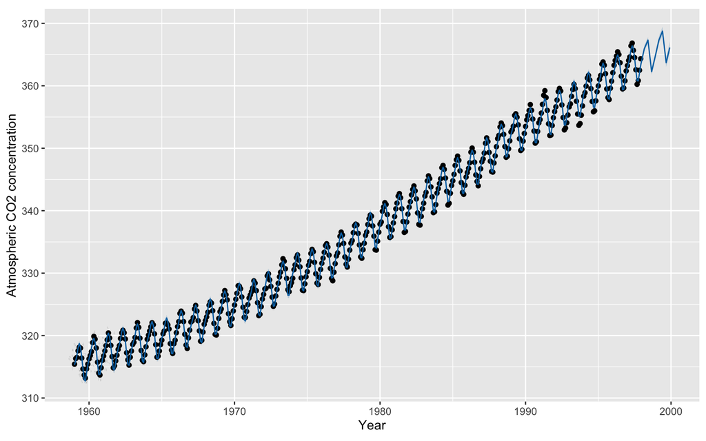

Where all the points in black are the recorded data points and the predicted points follow afterwards.

Upon review, we can clearly see that there is some seasonality to this data, meaning there is a pattern to the behaviour of the data.

Within one yearly cycle, January to January, the concentration of carbon dioxide in the atmosphere rises up to its peak around May and June and then it starts to fall down until it reaches its lowest concentration around October. This pattern is clear throughout the data and follows through with the predicted values that we obtained as in both 1998 and 1999, June had the highest predicted values and September had the lowest predicted values.

In addition to the seasonality, we can see that when comparing months in consecutive years, the carbon dioxide concentration has been constantly increasing but it is quite difficult to look exactly at the trend. So I decided to remove the seasonality from the data and create a new model which I then plotted with the new predictions.

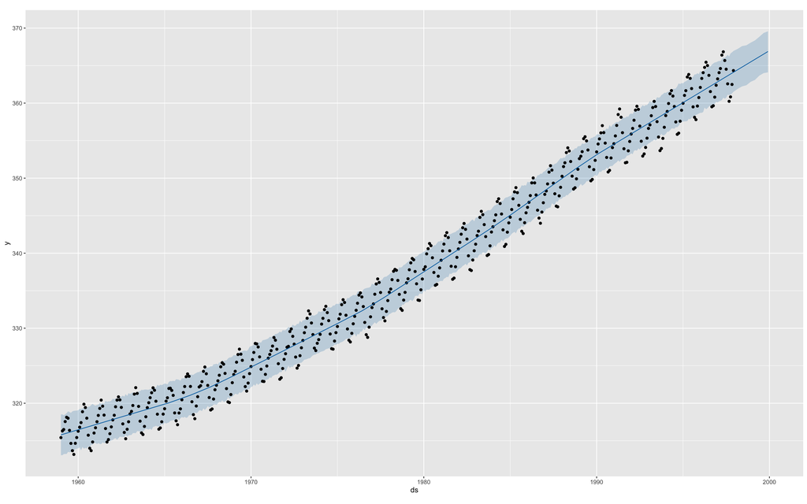

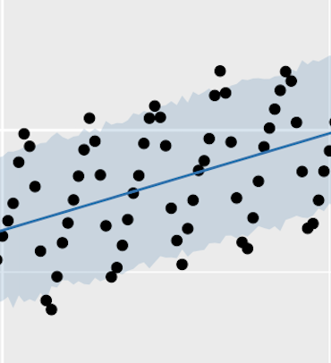

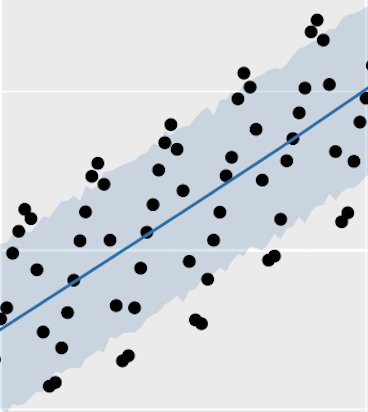

Here the image on the left shows the gradient of the line between 1960 and 1965 and the image on the right shows the gradient of the line between 1980 and 1985. We can clearly see here that the rate at which the carbon dioxide concentrations are increasing is much faster in 1980 than in 1960.

To get better idea of the rate at which the CO2 levels have been rising a linear regression of the data can be done.

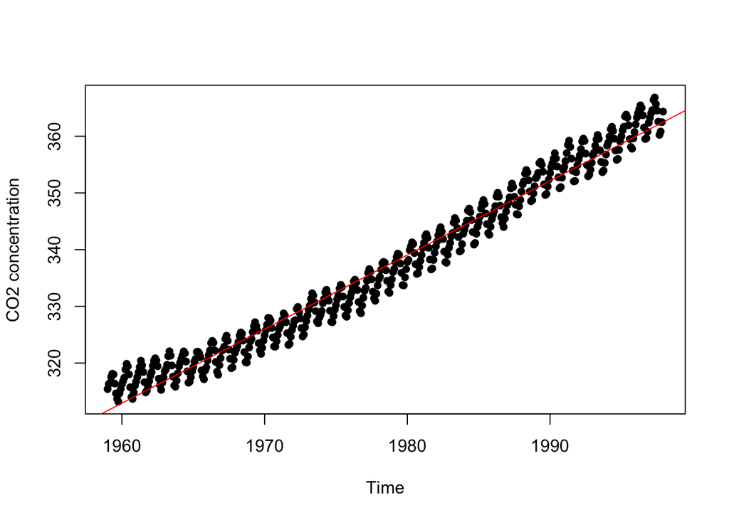

Looking at the plot, we can see the regression line in red which gives us an idea of how it is increasing overall. The regression analysis also gave us a value for the slope of the curve which was 1.308. This isn’t a significantly large value however, over a long period of time it would add up.